# An Introduction to the exprso Package

Thomas Quinn

2019-03-23

## Introduction

In this tutorial, we present the exprso package for R, a library built to tackle a wide variety of supervised machine learning tasks, including the construction of ensemble classifiers. We designed exprso using a modular framework, whereby each function acts as a self-contained, yet interchangeable, part of the whole. With these modules, the investigator has access to multiple tools that they can combine in almost any sequence to build their own personalized machine learning pipelines on the fly. In this way, we balance the simplicity of automation with endless customization, all while maintaining software extensibility.

We can install the most recent version of exprso directly from CRAN.

```r
install.packages("exprso")
library(exprso)
```

## exprso Objects

This package contains five object types that handle the machine learning procedures:

- **ExprsArray** Stores feature and annotation data as well as relevant feature selection history. The sub-classes `ExprsBinary` and `ExprsMulti` handle dichotomous and multi-class data, respectively.
- **ExprsModel** Stores the trained classifier as well as the relevant feature selection history needed to deploy the classifier on an independent dataset. The sub-classes `ExprsMachine` and `ExprsModule` handle dichotomous and multi-class classifiers, respectively.
- **ExprsPipeline** Stores a summary of high-throughput classification results and the classifier objects.
- **ExprsEnsemble** Stores any number of classifier objects which function a single ensemble classifier.
- **ExprsPredict** Stores the results of classifier prediction as one of three measures.

## exprso Functions

Functions included in this package rely on the objects listed above. Some of these functions return an updated version of the same object type provided, while others return a new object type. We have adopted a nomenclature to help organize the functions available in this package. In this scheme, most functions have a few letters in the beginning of their name which designate their use:

- **array** Imports data. Returns an `ExprsArray` object.
- **mod** Pre-processes `ExprsArray` objects. Returns an updated `ExprsArray` object. See `?mod`.
- **split** Splits `ExprsArray` objects into training and test sets. Returns an `ExprsArray` list. See `?split`.
- **fs** Selects features. Returns an updated `ExprsArray` object. See `?fs`.
- **build** Builds models and ensembles. Returns an `ExprsModel` or `ExprsEnsemble` object. See `?build`.
- **pl** Performs high-throughput analysis. Usually returns an `ExprsPipeline` object. See `?pl`.
- **pipe** Post-processes `ExprsPipeline` objects. Returns an updated `ExprsPipeline` object. See `?pipe`.

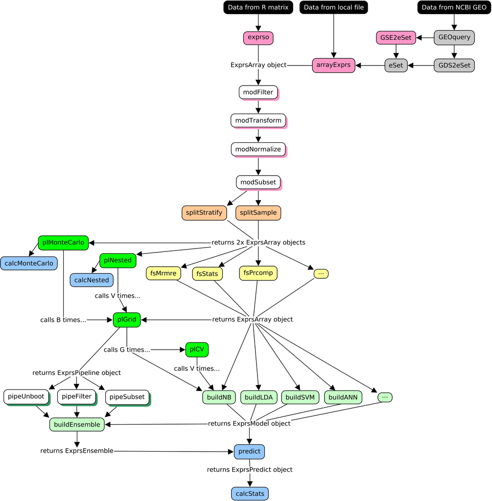

## Importing data

We recommend importing data using the `exprso` function. This function has two arguments. The first expects the data with samples as rows and features as columns. The second expects the annotations with samples as rows where the first column contains the outcome to predict.

```r
data(iris)
array <- exprso(iris[1:80, 1:4], iris[1:80, 5])
```

```
## [1] "Preparing data for binary classification."
## [1] "Converting binary labels to CONTROL / CASE."
## [1] "CONTROL: setosa (override with 'switch')"
```

## Subsetting data

To subset an `ExprsArray` object, we provide methods for the `[` and `$` operators that access the `@annot` annotations slot directly. Alternatively, one could use the `modSubset` or `subset` functions. Note that the “defineCase” column always contains the outcome to predict. For binary classification, this is always coded as “Case” and “Control”.

```r
sub <- array[array$defineCase == "Case", ]
sub <- modSubset(array, colBy = "defineCase", include = "Case")
sub <- subset(array, subset = array$defineCase == "Case")
```

## Splitting data

When performing classification, an investigator will typically withhold some percentage of the data to use later when assessing classifier performance, effectively splitting the data into two. The first dataset, called the *training set*, gets used to build the model, while the other, called the external validation or *test set*, gets used to evaluate the model. This package offers two convenience functions for splitting the data, `splitSample` and `splitStratify`. The former builds the training set based on simple random sampling (with or without replacement), assigning the remaining subjects to the test set. The latter builds the training set using stratified random sampling. These functions both return a list of two `ExprsArray` objects corresponding to the training set and test set respectively. Below, we use the `splitStratify` function to build the training and test sets through a stratified random sample across the dichotomous (binary) classification annotation.

```r
arrays <-
  splitStratify(array,
                percent.include = 67,
                colBy = NULL)

array.train <- arrays[[1]]
```

## Balancing data

All subjects not included in the training set (based on the `percent.include` argument) will automatically get assigned to the test set. Sometimes, when using `splitStratify` on a dataset with an unequal number of annotated subjects, the resultant test set may contain relative class frequencies that differ from the training set. If needed, we can fix this so-called “imbalance” at the cost of reducing sample size by performing `splitStratify` a second time. Now, we will use the test set as the input and let `percent.include = 100` (keeping the other parameters the same). This will split the test set such that the new “training set” (i.e., slot 1) now contains the *balanced test set* and the new “test set” (i.e., slot 2) now contains the “spillover”.

```r
balance <-
  splitStratify(arrays[[2]],
                percent.include = 100,
                colBy = NULL)

array.test <- balance[[1]]
```

## Selecting features

Considering the high-dimensionality of many datasets, it is prudent and often necessary to prioritize which features to include during classifier construction. This package provides functions for some of the most frequently used feature selection methods. Each function works as a self-contained wrapper that (1) pre-processes the `ExprsArray` input, (2) performs the feature selection, and (3) returns an `ExprsArray` output with an updated feature selection history. These histories get passed along at every step of the way until they eventually get used to pre-process an unlabeled dataset during classifier deployment (i.e., prediction).

One feature selection function is `fsStats`. This performs basic feature selection based on simple statistical tests. Specifically, this function will rank features using either the Student’s $t$-test or the Kolmogorov-Smirnov test. Below, the argument `top = 0` tells tells the program to rank all features.

```r
array.train <-
  fsStats(array.train, top = 0, how = "t.test")
```

The argument `top` specifies either the names or the number of features to supply *to* the feature selection method, not what the user intends to retrieve *from* the feature selection method. When calling the first feature selection method (or the first build method, if skipping feature selection), a numeric `top` argument will select a “top ranked” feature set according to their default order in the `ExprsArray` input. Then, because each feature selection method returns an `ExprsArray` object with the features implicitly (re-)ranked, all subsequent numeric `top` arguments will select a “top ranked” feature set according to the results of the previous feature selection method. For example, the third feature selection call draws the top features from the second feature ranking. The user may deploy, in tandem, any number of these functions in whatever order they choose.

Another feature selection function is `fsPrcomp`. This performs dimension reduction by way of principal components analysis (**PCA**). Like the feature selection steps, all dimension reduction models get saved in the `ExprsArray` history to deploy later on a test set. Below, we use the top 50 features for PCA.

```r
array.train <-
  fsPrcomp(array.train, top = 50)
```

The other feature selection methods included in this package all follow the same use pattern. Below, we plot the first three components of the training set in 3-dimensional space.

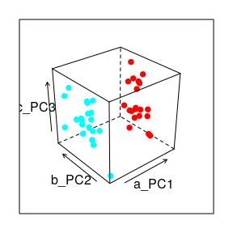

```r
plot(array.train)
```

## Constructing classifiers

This package provides functions for several supervised machine learning methods, including support vector machines, artificial neural networks, random forests, and more. These functions require an `ExprsArray` object as input and return an `ExprsModel` object as output. This `ExprsModel` object contains the feature selection history that led up to classifier construction as well as the classifier itself. Below, we build an artificial neural network with five intermediate nodes in the hidden layer using the top 10 components from the *training set* above.

```r
mach <-
  buildANN(array.train, top = 10, size = 5)
```

```
## Setting rang to 0.38759719586878 (default behavior, override explicitly)...
```

```
## Setting maxit to 1000 (default behavior, override explicitly)...
```

## Deploying classifiers

We deploy an `ExprsModel` object using `predict`. This function returns an `ExprsPredict` object containing the prediction results in three forms: prediction, probability, and decision boundary predictions. The probability and decision boundary predictions relate to one another by a logistic transformation. The prediction (`@pred`) slot converts these metrics into a single “all-or-nothing” class label assignment.

Another function, `calcStats`, allows us to compare the prediction results against the actual class labels. The `aucSkip` argument specifies whether to calculate the area under the receiver operating characteristic (**ROC**) curve. Note, however, that performance metrics calculated using the ROC curve may differ from those calculated using a confusion matrix because the former may adjust the discrimination threshold to optimize sensitivity and specificity. The discrimination threshold is automatically chosen as the point along the ROC curve which minimizes the Euclidean distance from (0, 1). Below, we deploy a classifier on the *test set*, then use the result to calculate classifier performance.

```r
pred <-
  predict(mach, array.test)
```

```
## Individual classifier performance:
## Arguments not provided in an ROCR AUC format. Calculating accuracy outside of ROCR...
## Classification confusion table:
##          actual
## predicted Control Case
##   Control      10    0
##   Case          0   10
##   acc sens spec
## 1   1    1    1
```

```r
calcStats(pred)
```

```
## Calculating accuracy using ROCR based on prediction probabilities...
```

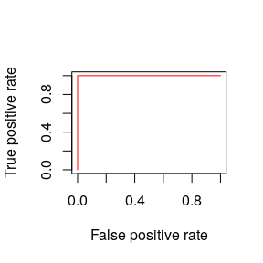

```
##   acc sens spec auc
## 1   1    1    1   1
```

## Pipeline methods

This package includes several functions named with the prefix `pl`. These “pipeline” functions exist to help with high-throughput learning. In other words, they wrap repetitive tasks into a single call. This includes extensive parameter searches as well as some elaborate cross-validation. Some of these `pl` functions can even have other `pl` functions embedded within them. For example, the function `plGrid` contains the function `plCV` for managing simple $v$-fold and leave-one-out cross-validation.

## High-throughput parameter searches

When constructing a classifier using a **build** method, we can only specify one set of parameters at a time. However, we often want to test models across a vast range of parameters. For this task, we provide the `plGrid` function. This function builds and deploys a model for each combination of all provided arguments. For example, calling `plGrid` with the arguments `how = "buildSVM"`, `top = c(3, 5, 10)`, `cost = 10^(-3:3)`, and `kernel = c("linear", "radial")` will yield 42 classifiers.

We note here that this function only accepts one `how` per run. To analyze the results of multiple `build` parameter searches jointly, combine the results of multiple `plGrid` function calls using `?conjoin`. We will also note that `plGrid` does not execute any data splitting or feature selection, both of which the user may perform beforehand. However, `plGrid` does allow the user to specify multiple *classifier sizes* by providing a numeric vector as the `top` argument.

The `plGrid` function can also calculate $v$-fold cross-validation accuracy at each step of the parameter search (toggled by supplying a non-`NULL` argument to `fold`). We emphasize, however, that the cross-validation method embedded within `plGrid` (i.e., `plCV`) does not re-select features with each fold, which may lead to overly-optimistic measures of classifier performance in the setting of prior feature selection.

Below, we run through a few different support vector machine builds, calculating leave-one-out cross-validation accuracy (i.e., via `fold = 0`) at each step.

```r
gs <-
  plGrid(array.train = array.train,
         array.valid = array.test,
         top = c(2, 4),
         how = "buildSVM",
         fold = 0,
         kernel = "linear",
         cost = 10^(-3:3)
)
```

The returned object contains two slots, `@summary` and `@machs`, which store the performance summary and corresponding `ExprsModel` objects, respectively. The performance summary contains columns detailing the parameters used to build each machine along with performance metrics for the training set (and test set, if provided). Columns named with “train” describe training set performances. Columns named with “valid” describe test set performances. The column, `"train.plCV"`, contains the cross-validation accuracy, if performed. The returned `ExprsPipeline` object also contains an `ExprsModel` object for each entry in the performance summary.

To subset an `ExprsPipeline` object, we provide methods for the `[` and `$` operators that access the `@summary` performance summary slot directly. Alternatively, one could use the `pipeSubset` or `subset` functions.

```r
sub <- gs[gs$cost == 1, ]
sub <- pipeSubset(gs, colBy = "cost", include = 1)
sub <- subset(gs, subset = gs$cost == 1)
```

## Other cross-validation

The exprso package also provides a means by which to perform elaborate cross-validation, including Monte Carlo style and 2-layer “nested” cross-validation. Analogous to how `plGrid` manages multiple build and predict tasks, these pipelines (i.e., `plMonteCarlo` and `plNested`) effectively manage multiple `plGrid` tasks. In order to organize the sheer number of arguments necessary to execute these functions, we have implemented argument handler functions (i.e., `ctrlSplitSet`, `ctrlFeatureSelect`, and `ctrlGridSearch`) that handle data splitting, feature selection, and grid searching, respectively.

In simplest terms, `plMonteCarlo` and `plNested` use a single training set to calculate classifier performances on a withheld *internal validation set*. This *internal validation set* serves as a kind of proxy for a statistically independent test set. The main difference between `plMonteCarlo` and `plNested` stems from how the *internal validation set* gets constructed. On one hand, the `plMonteCarlo` method uses the `ctrlSplitSet` argument handler to split the training set into a *training subset* and an *intenral validation set* with each bootstrap. On the other hand, the `plNested` method splits the training set into $v$-folds, treating each fold as an *internal validation set* while treating those outside that fold as the *training subset*.

For clarity, we call any performance measured on an *internal validation set* as the **outer-loop** cross-validation performance and any cross-validation accuracy measured using the *training subset* (i.e., via `plGrid`) the **inner-loop** cross-validation performance. In the performance summaries of the `ExprsPipeline` objects returned by `plMonteCarlo` and `plNested`, columns named with “train” describe *training subset* performances while columns named with “valid” describe *internal validation set* performances. Although the **inner-loop** cross-validation performances (i.e., via `plCV`) can still over-estimate cross-validation through prior feature selection, the **outer-loop** cross-validation performances derive from classifiers that have undergone feature selection anew with each bootstrap or fold. However, we emphasize here that performing feature selection on a training set *prior* to the use of `plMonteCarlo` or `plNested` can still result in overly optimistic **outer-loop** cross-validation performances.

In the example below, we perform five iterations of `plMonteCarlo` using the original training set as it existed before it underwent any feature selection (i.e., the first slot of the object `arrays`). With each iteration, we (1) sample the subjects randomly through bagging (i.e., random sampling with replacement), (2) perform feature selection using the Student’s t-test, and then (3) execute a grid-search across multiple support vector machine parameters and classifier sizes. In this framework, the user could instead perform any number of feature selection tasks simply by supplying a list of multiple `ctrlFeatureSelect` argument handlers to the `ctrlFS` argument below.

```r
ss <-
  ctrlSplitSet(func = "splitSample", percent.include = 67, replace = TRUE)
fs <-
  ctrlFeatureSelect(func = "fsStats", top = 0, how = "t.test")
gs <-
  ctrlGridSearch(func = "plGrid",
                 how = "buildSVM",
                 top = c(2, 4),
                 kernel = "linear",
                 cost = 10^(-3:3),
                 fold = 10)
```

```r
boot <-
  plMonteCarlo(arrays[[1]],
               B = 5,
               ctrlSS = ss,
               ctrlFS = fs,
               ctrlGS = gs)
```

Next, we reduce the results of `plMonteCarlo` to a single performance metric by feeding the returned `ExprsPipeline` object through `calcMonteCarlo`. Note that this helper function will fail unless `plGrid` has called `plCV` during the parameter grid-search.

```r
calcMonteCarlo(boot, colBy = "valid.auc")
```

```
## Averaging best accuracies across all boots...
```

```
## [1] 1
```

## Ensemble classifiers

This package provides two ways to build ensemble classifiers. The first involves manually combining multiple `ExprsModel` objects together through the function `buildEnsemble` (or `?conjoin`). The second involves an orchestrated manipulation of an `ExprsPipeline` object through the `pipeFilter` function.

This latter approach filters an `ExprsPipeline` object in (up to) three steps. First, a threshold filter gets imposed, whereby any model with a performance less than the threshold filter, `how`, gets excluded. Second, a ceiling filter gets imposed, whereby any model with a performance greater than the ceiling filter, `gate`, gets excluded. Third, an arbitrary subset occurs, whereby the top *N* models in the `ExprsPipeline` object get selected based on the argument `top`. In the case that the `@summary` slot contains the column “boot” (e.g., in the results of `plMonteCarlo`), `pipeFilter` selects the top *N* models for *each* unique bootstrap. The user may skip any one of these three filter steps by setting the respective argument to 0.

When calling the `buildEnsemble` method for an `ExprsPipeline` object, any classifiers remaining after the `pipeFilter` filter will get assembled into a single ensemble classifier. Ensemble classifiers get stored as an `ExprsEnsemble` object which is simply a container for a list of multiple `ExprsModel` objects.

In the example below, we we will build an ensemble using the single best classifier from each `plMonteCarlo` bootstrap, and then deploy that ensemble on the withheld *test set* from above.

```r
ens <- buildEnsemble(boot, top = 1, colBy = "valid.auc")
pred <- predict(ens, array.test, how = "majority")
```

```
## Arguments not provided in an ROCR AUC format. Calculating accuracy outside of ROCR...
## Classification confusion table:
##          actual
## predicted Control Case
##   Control      10    0
##   Case          0   10
```

```
##   acc sens spec
## 1   1    1    1
```

Owing to how the `pipeFilter` function handles `ExprsPipeline` objects that contain a “boot” column in the performance summary (i.e., `@summary`), we include the `pipeUnboot` function to rename this “boot” column to “unboot”. To learn more about how `ExprsEnsemble` predicts class labels, we refer the user to the documentation, `?'exprso-predict'`. In addition, we encourage the user to visit the documentation, `?'ExprsPipeline-class'` and `?'ExprsEnsemble-class'`.

## Multi-class classification methods

We conclude this vignette by alerting the user that the exprso package also includes a framework for performing multi-class classification in an automated manner. These methods use the “1-vs-all” approach to multi-class classification, whereby each individual class label has a turn getting treated as the positive class label in a dichotomous (binary) scheme. Then, the results of each iteration get integrated into a single construct. To learn more about multi-class classification, we refer the user to the documentation for `?doMulti` and the companion vignette, “Advanced Topics for the exprso package”.

## Regression methods

The exprso package framework also extends to building and deploying regression models to predict continuous outcomes. All pipeline and ensemble methods discussed here also apply to regression, although some `fs` and `build` methods work only for classification.

## Final remarks

Thank you for your interest in exprso. Although we have made tremendous progress in formalizing this library in a reliable package framework, some of the tools included here may change. To the best of knowledge, we have followed the machine learning “best practices” when developing this software, but if you know better than us, please let us know! File any and all issues at [GitHub](http://www.github.com/tpq/exprso/issues). In addition, we always welcome suggestions for new tools that we could include in future releases. Happy learning!